# TRGN510_FinalProject

## Find and set working directory

```r
getwd()
```

```
## [1] "/Users/wendy/Desktop/TRGN510_FinalProject"
```

```r
setwd("/Users/wendy/Desktop/TRGN510_FinalProject")
```

## Load required packages

```r
library(Glimma)
library(edgeR)
library(limma)
library(Homo.sapiens)
```

## Load in the data

Black male and white male data are in different folders, so I make a 2D-list. I put all the file names in the black male folder in the first row of 2D-list, and all the file names in the white male folder in the second row of 2D-list. Then, I make a for loop to read each file in the folders.

```r
path <- paste("/Users/wendy/Desktop/TRGN510_FinalProject",'data',sep="/")

folders <- list.dirs(path)
folders <- folders[2:length(folders)]
store <- list()
for(i in 1:length(folders)){
  store = cbind(store, list.files(folders[i],pattern = "htseq.counts"))
}
for(i in 1:length(folders)){
  store[,i] = paste(folders[i],store[,i],sep = '/')
}
```

## Group the data

Read each of the files into R and combine into a dataframe called as “x”

```r
x <- readDGE(store, columns=c(1,2))
```

```
## Meta tags detected: __no_feature, __ambiguous, __too_low_aQual, __not_aligned, __alignment_not_unique
```

```r
class(x)
```

```
## [1] "DGEList"
## attr(,"package")
## [1] "edgeR"
```

This funtion shows the dimensions of the dataframe. There are 60487 genes in each file and there are 30 files (15 black males and 15 white males).

```r
dim(x)
```

```
## [1] 60487    30
```

## Organize sample information

DGEList-oject contains a `samples` dataframe. The samplenames are complicated, so I name them black male 1 to 15, and white male 1 to 15.

```r
samplenames <- c(rep("black_male",15), rep("white_male",15))
for( i in 1:(length(samplenames)/2)){
  samplenames[i] = paste(samplenames[i], as.character(i), sep='_')
}
for(i in 1:(length(samplenames)/2)){
  samplenames[length(samplenames)/2+i] = paste(samplenames[length(samplenames)/2+i], as.character(i), sep='_')
}
sampleNames
```

[output not shown]

```r
colnames(x) <- samplenames
```

The samples are grouped according to their ethnicity.

```r
group <- c(rep("black_male",15), rep("white_male",15))
x$samples$group <- group
x$samples
```

```
##                                                                                                                     files
## black_male_1  /Users/wendy/Desktop/TRGN510_FinalProject/data/black_male/01ae4201-f15c-4790-a7ea-41290808c5fa.htseq.counts
## black_male_2  /Users/wendy/Desktop/TRGN510_FinalProject/data/black_male/0ade05fe-5f98-477d-b7fa-c56ea93247cf.htseq.counts
## black_male_3  /Users/wendy/Desktop/TRGN510_FinalProject/data/black_male/13fe6d54-192b-4e93-92a8-02ab20e589ed.htseq.counts
## black_male_4  /Users/wendy/Desktop/TRGN510_FinalProject/data/black_male/175e2233-28a0-47c7-b395-19dd033b79d8.htseq.counts
## black_male_5  /Users/wendy/Desktop/TRGN510_FinalProject/data/black_male/1e69236e-5526-4bf1-8de5-35d50a71f227.htseq.counts
## black_male_6  /Users/wendy/Desktop/TRGN510_FinalProject/data/black_male/208e8d62-0277-404e-9246-55d36eb3ec7d.htseq.counts
## black_male_7  /Users/wendy/Desktop/TRGN510_FinalProject/data/black_male/38096336-4257-481c-b653-91804af5b2a1.htseq.counts
## black_male_8  /Users/wendy/Desktop/TRGN510_FinalProject/data/black_male/3c5c3b14-62d4-431a-ba60-cf2eb96d7e8a.htseq.counts
## black_male_9  /Users/wendy/Desktop/TRGN510_FinalProject/data/black_male/5d065eaa-e3a8-420e-b983-c1a80e713ac9.htseq.counts
## black_male_10 /Users/wendy/Desktop/TRGN510_FinalProject/data/black_male/6e264598-c25a-4d37-aa61-e3042c2265be.htseq.counts
## black_male_11 /Users/wendy/Desktop/TRGN510_FinalProject/data/black_male/7223f19a-017e-465b-b81b-bed54252c6b0.htseq.counts
## black_male_12 /Users/wendy/Desktop/TRGN510_FinalProject/data/black_male/891f9d70-e716-4fc9-b53e-f120da74eea3.htseq.counts
## black_male_13 /Users/wendy/Desktop/TRGN510_FinalProject/data/black_male/9f2932d6-bb5c-4ce0-9ea7-281a459fb64a.htseq.counts
## black_male_14 /Users/wendy/Desktop/TRGN510_FinalProject/data/black_male/dba87d20-a3ed-4ca3-93f7-0fe979f7923a.htseq.counts
## black_male_15 /Users/wendy/Desktop/TRGN510_FinalProject/data/black_male/ef700f61-d8b0-43d0-92d1-feec949adc72.htseq.counts
## white_male_1  /Users/wendy/Desktop/TRGN510_FinalProject/data/white_male/137d53ea-eb81-427d-ba2a-c346b904bf4d.htseq.counts
## white_male_2  /Users/wendy/Desktop/TRGN510_FinalProject/data/white_male/1d5e00c4-5c82-4035-8304-841ba81c61fd.htseq.counts
## white_male_3  /Users/wendy/Desktop/TRGN510_FinalProject/data/white_male/275f4377-31b7-436f-bded-1928c2b4f8e1.htseq.counts
## white_male_4  /Users/wendy/Desktop/TRGN510_FinalProject/data/white_male/3cd45be6-69d7-41c2-897a-44f8a70a451f.htseq.counts
## white_male_5  /Users/wendy/Desktop/TRGN510_FinalProject/data/white_male/3e5cd7b6-1f38-4ca3-a391-414b817a2203.htseq.counts
## white_male_6  /Users/wendy/Desktop/TRGN510_FinalProject/data/white_male/45db4b6d-e0d3-430f-b88e-cda7a388c2af.htseq.counts
## white_male_7  /Users/wendy/Desktop/TRGN510_FinalProject/data/white_male/6134c694-922d-4559-8f55-e03cc58d66dc.htseq.counts
## white_male_8  /Users/wendy/Desktop/TRGN510_FinalProject/data/white_male/679e7bab-b24d-415e-a341-da3955e8d47a.htseq.counts
## white_male_9  /Users/wendy/Desktop/TRGN510_FinalProject/data/white_male/777d1602-66be-4673-b69d-d651abf7bb35.htseq.counts
## white_male_10 /Users/wendy/Desktop/TRGN510_FinalProject/data/white_male/a60560b3-962b-4155-8aa5-46c8a5aaf9fa.htseq.counts
## white_male_11 /Users/wendy/Desktop/TRGN510_FinalProject/data/white_male/b197f3a7-4bb6-4e88-b1cf-9ad513873739.htseq.counts
## white_male_12 /Users/wendy/Desktop/TRGN510_FinalProject/data/white_male/ba514dbb-42e6-44fd-9c72-73839e1226e6.htseq.counts
## white_male_13 /Users/wendy/Desktop/TRGN510_FinalProject/data/white_male/d88996bb-af00-4040-b251-29807506ac1f.htseq.counts
## white_male_14 /Users/wendy/Desktop/TRGN510_FinalProject/data/white_male/d9c7a1f7-f303-4617-b46c-2003e871095b.htseq.counts
## white_male_15 /Users/wendy/Desktop/TRGN510_FinalProject/data/white_male/fe1e1f62-8e18-4400-9b25-2c439fa25b6f.htseq.counts
##                    group  lib.size norm.factors
## black_male_1  black_male  71160138            1
## black_male_2  black_male  70934815            1
## black_male_3  black_male  81954208            1
## black_male_4  black_male  79897973            1
## black_male_5  black_male  97337479            1
## black_male_6  black_male 115526522            1
## black_male_7  black_male  75482129            1
## black_male_8  black_male 102454441            1
## black_male_9  black_male  79896115            1
## black_male_10 black_male  78874227            1
## black_male_11 black_male  48806534            1
## black_male_12 black_male  82187721            1
## black_male_13 black_male  98973645            1
## black_male_14 black_male  87279294            1
## black_male_15 black_male  75793156            1
## white_male_1  white_male 122900608            1
## white_male_2  white_male  92430475            1
## white_male_3  white_male 109871986            1
## white_male_4  white_male  83837073            1
## white_male_5  white_male  66323630            1
## white_male_6  white_male 136130574            1
## white_male_7  white_male 106680305            1
## white_male_8  white_male  81264439            1
## white_male_9  white_male  75085058            1
## white_male_10 white_male  90811966            1
## white_male_11 white_male  74597670            1
## white_male_12 white_male  84378048            1
## white_male_13 white_male  96382018            1
## white_male_14 white_male  34462668            1
## white_male_15 white_male 132196285            1
```

## Organize gene annotations

I removed the all the digits after the decimal of Ensembl name, so it looks more similar to the key provided.

```r
geneid <- rownames(x)
geneid <-gsub("\\.\\d+$", "", geneid)
head(geneid)
```

```
## [1] "ENSG00000000005" "ENSG00000000419" "ENSG00000000457" "ENSG00000000460"
## [5] "ENSG00000000938" "ENSG00000000971"
```

I loaded “Homo.sapiens” library to get the information for this dataframe. The GeneIDs are related to the gene symbol and chromosome number.

```r
genes <- select(Homo.sapiens, keys=geneid, columns=c("SYMBOL", "TXCHROM"), keytype="ENSEMBL")
head(genes)
```

```
##           ENSEMBL   SYMBOL TXCHROM
## 1 ENSG00000000005     TNMD    chrX
## 2 ENSG00000000419     DPM1   chr20
## 3 ENSG00000000457    SCYL3    chr1
## 4 ENSG00000000460 C1orf112    chr1
## 5 ENSG00000000938      FGR    chr1
## 6 ENSG00000000971      CFH    chr1
```

I removed the duplicated genes from the dataset.

```r
genes <- genes[!duplicated(genes$ENSEMBL),]
x$genes <- genes
x
```

```
## An object of class "DGEList"
## $samples
##                                                                                                                    files
## black_male_1 /Users/wendy/Desktop/TRGN510_FinalProject/data/black_male/01ae4201-f15c-4790-a7ea-41290808c5fa.htseq.counts
## black_male_2 /Users/wendy/Desktop/TRGN510_FinalProject/data/black_male/0ade05fe-5f98-477d-b7fa-c56ea93247cf.htseq.counts
## black_male_3 /Users/wendy/Desktop/TRGN510_FinalProject/data/black_male/13fe6d54-192b-4e93-92a8-02ab20e589ed.htseq.counts
## black_male_4 /Users/wendy/Desktop/TRGN510_FinalProject/data/black_male/175e2233-28a0-47c7-b395-19dd033b79d8.htseq.counts
## black_male_5 /Users/wendy/Desktop/TRGN510_FinalProject/data/black_male/1e69236e-5526-4bf1-8de5-35d50a71f227.htseq.counts
##                   group lib.size norm.factors
## black_male_1 black_male 71160138            1
## black_male_2 black_male 70934815            1
## black_male_3 black_male 81954208            1
## black_male_4 black_male 79897973            1
## black_male_5 black_male 97337479            1
## 25 more rows ...
##
## $counts
##                     Samples
## Tags                 black_male_1 black_male_2 black_male_3 black_male_4
##   ENSG00000000005.5             4           15            3           56
##   ENSG00000000419.11         1270          985         1638         1453
##   ENSG00000000457.12          457          547          855          982
##   ENSG00000000460.15          112          125          191          248
##   ENSG00000000938.11         1212          567          802         1293
##                     Samples
## Tags                 black_male_5 black_male_6 black_male_7 black_male_8
##   ENSG00000000005.5            12           12           13            2
##   ENSG00000000419.11         1065         1814         1268          941
##   ENSG00000000457.12          931          653          890          381
##   ENSG00000000460.15          109          193          242          122
##   ENSG00000000938.11          666         2246          935          557
##                     Samples
## Tags                 black_male_9 black_male_10 black_male_11 black_male_12
##   ENSG00000000005.5            15            18            21             6
##   ENSG00000000419.11         1352          1358          1323           825
##   ENSG00000000457.12          872           969           311           520
##   ENSG00000000460.15          278           232           108           180
##   ENSG00000000938.11          850          1561           692          1097
##                     Samples
## Tags                 black_male_13 black_male_14 black_male_15 white_male_1
```

[output cut: 28 more lines]

```
##   ENSG00000000005.5              6             6
##   ENSG00000000419.11            38          1756
##   ENSG00000000457.12           179           993
##   ENSG00000000460.15            34           379
##   ENSG00000000938.11            57          1310
## 60482 more rows ...
##
## $genes
##           ENSEMBL   SYMBOL TXCHROM
## 1 ENSG00000000005     TNMD    chrX
## 2 ENSG00000000419     DPM1   chr20
## 3 ENSG00000000457    SCYL3    chr1
## 4 ENSG00000000460 C1orf112    chr1
## 5 ENSG00000000938      FGR    chr1
## 60482 more rows ...
```

## Transformations from the raw-scale

I transformed the data from its raw form to a scale that accounts for such library size differences. “cpm” means counts per million, and “lcpm” means log of counts per million.

```r
cpm <- cpm(x)
lcpm <- cpm(x, log=TRUE)
```

L is the average library size in millions, and M is the median of the library size in millions. For this dataset, the average library size is about 87.8 million.

```r
L <- mean(x$samples$lib.size) * 1e-6
M <- median(x$samples$lib.size) * 1e-6
c(L, M)
```

```
## [1] 87.79704 83.01240
```

This is the summary of the lcpm calculation.

```r
summary(lcpm)
```

```
##   black_male_1      black_male_2      black_male_3      black_male_4
##  Min.   :-5.4561   Min.   :-5.4561   Min.   :-5.4561   Min.   :-5.4561
##  1st Qu.:-5.4561   1st Qu.:-5.4561   1st Qu.:-5.4561   1st Qu.:-5.4561
##  Median :-4.7629   Median :-4.7611   Median :-4.8373   Median :-4.8244
##  Mean   :-2.5473   Mean   :-2.6606   Mean   :-2.6001   Mean   :-2.4155
##  3rd Qu.:-0.2076   3rd Qu.:-0.5751   3rd Qu.:-0.3598   3rd Qu.: 0.1199
##  Max.   :17.6732   Max.   :17.8412   Max.   :17.4313   Max.   :17.7961
##   black_male_5      black_male_6      black_male_7      black_male_8
##  Min.   :-5.4561   Min.   :-5.4561   Min.   :-5.4561   Min.   :-5.4561
##  1st Qu.:-5.4561   1st Qu.:-5.4561   1st Qu.:-5.4561   1st Qu.:-5.4561
##  Median :-4.9191   Median :-4.9914   Median :-4.7947   Median :-4.9416
##  Mean   :-2.6547   Mean   :-2.6537   Mean   :-2.3943   Mean   :-2.7952
##  3rd Qu.:-0.3341   3rd Qu.:-0.5368   3rd Qu.: 0.1408   3rd Qu.:-0.6491
##  Max.   :18.3506   Max.   :17.8954   Max.   :17.5212   Max.   :18.6557
##   black_male_9     black_male_10     black_male_11      black_male_12
##  Min.   :-5.4561   Min.   :-5.4561   Min.   :-5.45610   Min.   :-5.4561
##  1st Qu.:-5.4561   1st Qu.:-5.4561   1st Qu.:-5.45610   1st Qu.:-4.8387
##  Median :-4.8243   Median :-4.8177   Median :-4.53053   Median :-3.0575
##  Mean   :-2.5286   Mean   :-2.3967   Mean   :-2.49288   Mean   :-1.8511
##  3rd Qu.:-0.1141   3rd Qu.: 0.1546   3rd Qu.: 0.03808   3rd Qu.: 0.3098
##  Max.   :17.3703   Max.   :17.6033   Max.   :17.70589   Max.   :17.9686
##  black_male_13    black_male_14      black_male_15        white_male_1
##  Min.   :-5.456   Min.   :-5.45610   Min.   :-5.456100   Min.   :-5.456
##  1st Qu.:-5.456   1st Qu.:-5.45610   1st Qu.:-5.456100   1st Qu.:-5.456
##  Median :-4.926   Median :-4.86829   Median :-4.796917   Median :-5.015
##  Mean   :-2.599   Mean   :-2.45531   Mean   :-2.440106   Mean   :-2.650
##  3rd Qu.:-0.454   3rd Qu.:-0.00482   3rd Qu.:-0.001268   3rd Qu.:-0.623
##  Max.   :17.767   Max.   :17.58736   Max.   :17.769730   Max.   :17.618
##   white_male_2      white_male_3      white_male_4      white_male_5
##  Min.   :-5.4561   Min.   :-5.4561   Min.   :-5.4561   Min.   :-5.4561
##  1st Qu.:-5.4561   1st Qu.:-5.4561   1st Qu.:-5.4561   1st Qu.:-5.4561
##  Median :-4.8954   Median :-4.3195   Median :-4.8486   Median :-4.7233
##  Mean   :-2.3591   Mean   :-2.3003   Mean   :-2.5905   Mean   :-2.3178
##  3rd Qu.: 0.2393   3rd Qu.: 0.2483   3rd Qu.:-0.2621   3rd Qu.: 0.2434
##  Max.   :17.4597   Max.   :17.7426   Max.   :17.6781   Max.   :17.6639
##   white_male_6      white_male_7      white_male_8       white_male_9
##  Min.   :-5.4561   Min.   :-5.4561   Min.   :-5.45610   Min.   :-5.4561
##  1st Qu.:-5.4561   1st Qu.:-5.4561   1st Qu.:-5.45610   1st Qu.:-5.4561
##  Median :-4.7381   Median :-4.9589   Median :-4.83299   Median :-4.7919
##  Mean   :-2.5976   Mean   :-2.6661   Mean   :-2.45033   Mean   :-2.3218
##  3rd Qu.:-0.4009   3rd Qu.:-0.4255   3rd Qu.:-0.06191   3rd Qu.: 0.3651
##  Max.   :18.3062   Max.   :17.8565   Max.   :17.46355   Max.   :17.4968
##  white_male_10     white_male_11     white_male_12      white_male_13
##  Min.   :-5.4561   Min.   :-5.4561   Min.   :-5.45610   Min.   :-5.4561
##  1st Qu.:-5.4561   1st Qu.:-5.4561   1st Qu.:-5.45610   1st Qu.:-5.4561
##  Median :-4.8872   Median :-4.7885   Median :-4.42716   Median :-4.9146
##  Mean   :-2.5434   Mean   :-2.6627   Mean   :-2.44046   Mean   :-2.6612
##  3rd Qu.:-0.2367   3rd Qu.:-0.4742   3rd Qu.:-0.05147   3rd Qu.:-0.5204
##  Max.   :17.8231   Max.   :17.9924   Max.   :17.82281   Max.   :17.9262
##  white_male_14     white_male_15
##  Min.   :-5.4561   Min.   :-5.45610
##  1st Qu.:-5.4561   1st Qu.:-5.45610
##  Median :-3.6293   Median :-4.72132
##  Mean   :-2.5133   Mean   :-2.42520
##  3rd Qu.: 0.1705   3rd Qu.:-0.06913
##  Max.   :19.1314   Max.   :17.73860
```

## Removing genes that are lowly expressed

All datasets include genes that are expressed and not expressed, so we want to remove some genes that are lowly expressed and do not contribute to the statistical analysis.

```r
table(rowSums(x$counts==0)==9)
```

```
##
## FALSE  TRUE
## 59811   676
```

EdgeR package provides an easy way to remove these lowly expressed genes.

```r
keep.exprs <- filterByExpr(x, group=group)
x <- x[keep.exprs,, keep.lib.sizes=FALSE]
dim(x)
```

```
## [1] 20902    30
```

The number of genes is reduced from 60487 to 20902. The `RColorBrewer` package allows us to create the figure. The following code is to produce the figure that is raw data and filtered data.

```r
lcpm.cutoff <- log2(10/M + 2/L)
library(RColorBrewer)
nsamples <- ncol(x)
col <- brewer.pal(nsamples, "Paired")
```

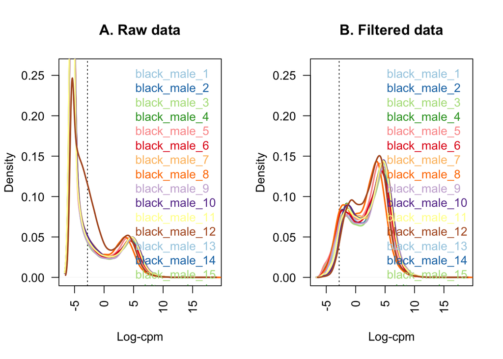

```r
par(mfrow=c(1,2))
plot(density(lcpm[,1]), col=col[1], lwd=2, ylim=c(0,0.26), las=2, main="", xlab="")
title(main="A. Raw data", xlab="Log-cpm")
abline(v=lcpm.cutoff, lty=3)
for (i in 2:nsamples){
den <- density(lcpm[,i])
lines(den$x, den$y, col=col[i], lwd=2)
}
legend("topright", samplenames, text.col=col, bty="n")
lcpm <- cpm(x, log=TRUE)
plot(density(lcpm[,1]), col=col[1], lwd=2, ylim=c(0,0.26), las=2, main="", xlab="")
title(main="B. Filtered data", xlab="Log-cpm")
abline(v=lcpm.cutoff, lty=3)
for (i in 2:nsamples){
den <- density(lcpm[,i])
lines(den$x, den$y, col=col[i], lwd=2)
}
legend("topright", samplenames, text.col=col, bty="n")
```

## Normalizing gene expression distributions

EdgeR package provides `calcNormFactors` function for statistical analysis. The normalization factors are stored in a dataset called `norm.factors`.

```r
x <- calcNormFactors(x, method = "TMM")
x$samples$norm.factors
```

```
##  [1] 1.1182190 0.9529122 1.1190138 1.2311480 0.8134900 0.8902969 1.2478293
##  [8] 0.5793794 1.2444527 1.2625266 1.1503150 0.8657577 0.9830556 1.1528950
## [15] 1.1243231 1.0736331 1.3187255 1.0910502 0.9646140 1.2786156 0.8022666
## [22] 0.9151107 1.1580491 1.2810019 1.0861181 0.9228678 1.0719933 0.9335922
## [29] 0.2821230 1.1111074
```

```r
x2 <- x
x2$samples$norm.factors <- 1
x2$counts[,1] <- ceiling(x2$counts[,1]*0.05)
x2$counts[,2] <- x2$counts[,2]*5
```

The plot below shows the expression distribution of samples for unnormalized data.

```
##  [1] 0.06808722 4.89340826 1.14591805 1.26980292 0.85389955 0.94537557
##  [7] 1.30977470 0.62310985 1.25162373 1.29496902 1.19934435 0.93544037
## [13] 1.00549238 1.22052320 1.19682428 1.06653460 1.36352238 1.13224396
## [19] 0.99960831 1.37590019 0.85026854 0.92093608 1.21075862 1.36384607
## [25] 1.12816987 0.92984185 1.12078591 0.97704400 0.29962247 1.16309459
```

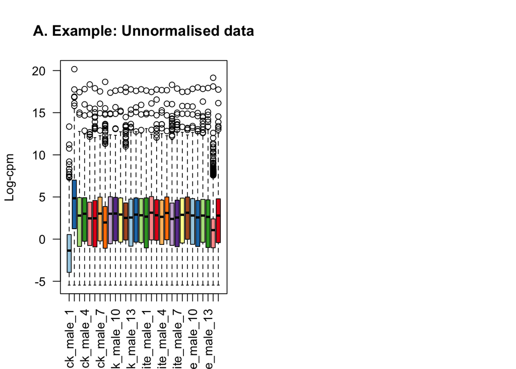

```r
par(mfrow=c(1,2))
lcpm <- cpm(x2, log=TRUE)
boxplot(lcpm, las=2, col=col, main="")
title(main="A. Example: Unnormalised data",ylab="Log-cpm")
x2 <- calcNormFactors(x2)
x2$samples$norm.factors
```

The plot below shows the expression distribution of samples for normalized data.

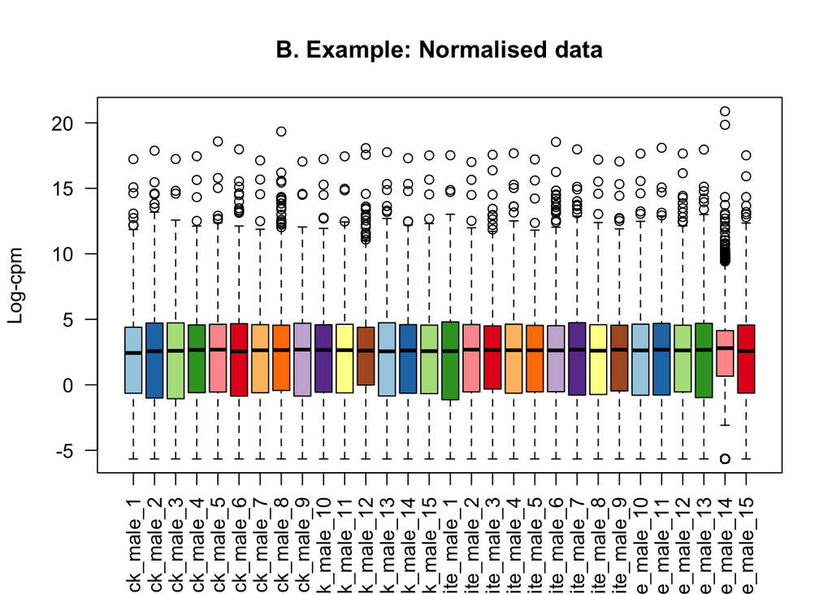

```r
lcpm <- cpm(x2, log=TRUE)
boxplot(lcpm, las=2, col=col, main="")
title(main="B. Example: Normalised data",ylab="Log-cpm")
```

## Unsupervised clustering of samples

The MDS plot is used to check the similarities and dissimilarities in a sample. The differences can show you the expected results of the differential expression analysis. The “plotMDS” function allows us to create the graph.

```r
library(limma)
library(Glimma)
lcpm <- cpm(x, log=TRUE)
par(mfrow=c(1,2))
group
```

```
##  [1] "black_male" "black_male" "black_male" "black_male" "black_male"
##  [6] "black_male" "black_male" "black_male" "black_male" "black_male"
## [11] "black_male" "black_male" "black_male" "black_male" "black_male"
## [16] "white_male" "white_male" "white_male" "white_male" "white_male"
## [21] "white_male" "white_male" "white_male" "white_male" "white_male"
## [26] "white_male" "white_male" "white_male" "white_male" "white_male"
```

```r
levels(group) <-  brewer.pal(nlevels(group), "Set1")
```

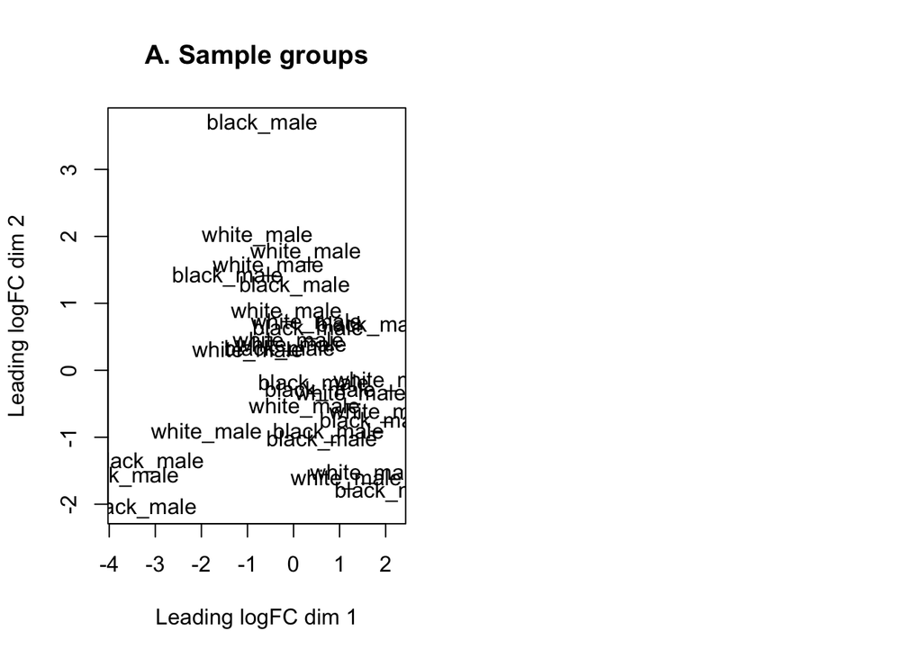

```r
col.group <- as.character(group)
col.group <- c("purple","orange")[group]
plotMDS(lcpm, labels=group, col=col.group)
title(main="A. Sample groups")
```

```r
glMDSPlot(lcpm,groups = group)
```

## Differential Expression Analysis

## Create a design matrix and contrasts

This is the differential expression analysis. First, I create a design matrix with both groups of data.

```r
design <- model.matrix(~0+group)
colnames(design) <- gsub("group", "", colnames(design))
design
```

```
##    black_male white_male
## 1           1          0
## 2           1          0
## 3           1          0
## 4           1          0
## 5           1          0
## 6           1          0
## 7           1          0
## 8           1          0
## 9           1          0
## 10          1          0
## 11          1          0
## 12          1          0
## 13          1          0
## 14          1          0
```

[output cut: 21 more lines]

This is the contrasts for the two groups created and stored in a matrix.

```r
contr.matrix <- makeContrasts(
   BlackVsWhite = black_male-white_male,
   levels = colnames(design))
contr.matrix
```

```
##             Contrasts
## Levels       BlackVsWhite
##   black_male            1
##   white_male           -1
```

This is the voom plot.

```
## An object of class "EList"
## $genes
##           ENSEMBL   SYMBOL TXCHROM
## 1 ENSG00000000005     TNMD    chrX
## 2 ENSG00000000419     DPM1   chr20
## 3 ENSG00000000457    SCYL3    chr1
## 4 ENSG00000000460 C1orf112    chr1
## 5 ENSG00000000938      FGR    chr1
## 20897 more rows ...
##
## $targets
##                                                                                                                    files
## black_male_1 /Users/wendy/Desktop/TRGN510_FinalProject/data/black_male/01ae4201-f15c-4790-a7ea-41290808c5fa.htseq.counts
## black_male_2 /Users/wendy/Desktop/TRGN510_FinalProject/data/black_male/0ade05fe-5f98-477d-b7fa-c56ea93247cf.htseq.counts
## black_male_3 /Users/wendy/Desktop/TRGN510_FinalProject/data/black_male/13fe6d54-192b-4e93-92a8-02ab20e589ed.htseq.counts
## black_male_4 /Users/wendy/Desktop/TRGN510_FinalProject/data/black_male/175e2233-28a0-47c7-b395-19dd033b79d8.htseq.counts
## black_male_5 /Users/wendy/Desktop/TRGN510_FinalProject/data/black_male/1e69236e-5526-4bf1-8de5-35d50a71f227.htseq.counts
##                   group lib.size norm.factors
## black_male_1 black_male 79526492    1.1182190
## black_male_2 black_male 67456155    0.9529122
## black_male_3 black_male 91515595    1.1190138
## black_male_4 black_male 98288721    1.2311480
## black_male_5 black_male 79110456    0.8134900
## 25 more rows ...
##
## $E
##                     Samples
## Tags                 black_male_1 black_male_2 black_male_3 black_male_4
##   ENSG00000000005.5    -4.1434387   -2.1216819    -4.708591    -0.798775
##   ENSG00000000419.11    3.9978170    3.8688339     4.162214     3.886361
##   ENSG00000000457.12    2.5242643    3.0208370     3.224678     3.321360
##   ENSG00000000460.15    0.5004175    0.8956654     1.065255     1.338148
##   ENSG00000000938.11    3.9304054    3.0725984     3.132412     3.718110
##                     Samples
## Tags                 black_male_5 black_male_6 black_male_7 black_male_8
##   ENSG00000000005.5    -2.6619403    -3.038902    -2.801429    -4.567887
##   ENSG00000000419.11    3.7515184     4.142599     3.752591     3.989002
##   ENSG00000000457.12    3.5576155     2.669286     3.242155     2.685724
##   ENSG00000000460.15    0.4689906     0.913432     1.365524     1.046823
##   ENSG00000000938.11    3.0746646     4.450706     3.313277     3.233013
```

[output cut: 70 more lines]

```
## [1,] 0.4534630 0.7110664
## [2,] 1.0501535 3.5657887
## [3,] 0.8809172 3.1884954
## [4,] 0.6523933 1.7532726
## [5,] 1.0083294 3.5088206
## 20897 more rows ...
##
## $design
##   black_male white_male
## 1          1          0
## 2          1          0
## 3          1          0
## 4          1          0
## 5          1          0
## 25 more rows ...
```

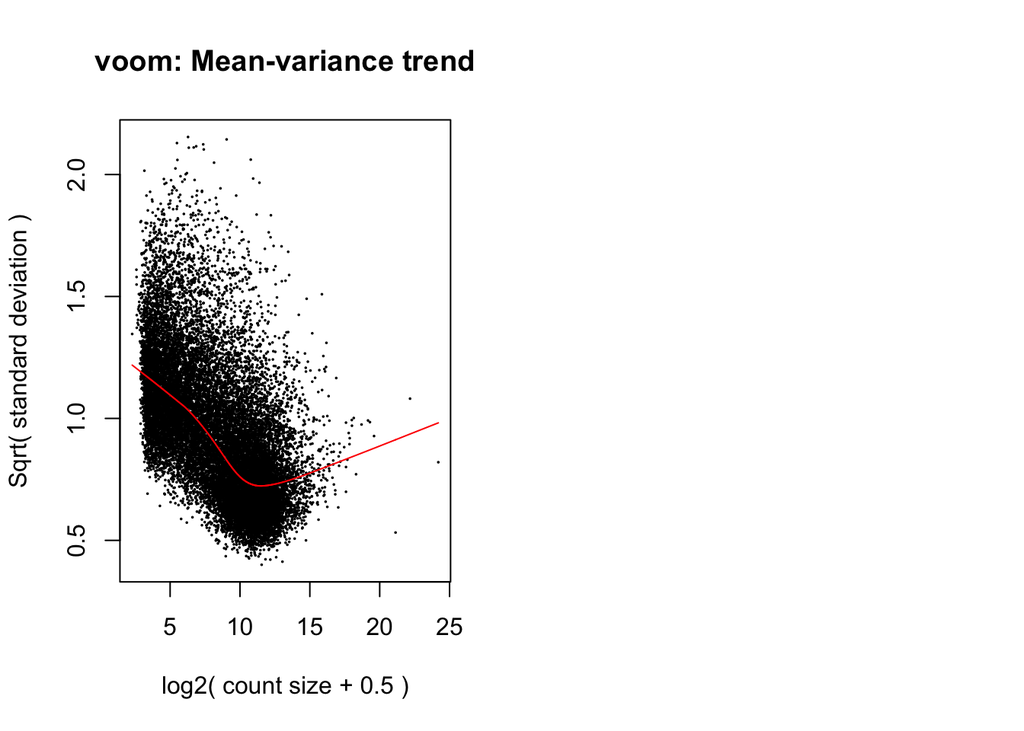

```r
par(mfrow=c(1,2))
v <- voom(x, design, plot=TRUE)
v
```

This is our final mean-variance trend.

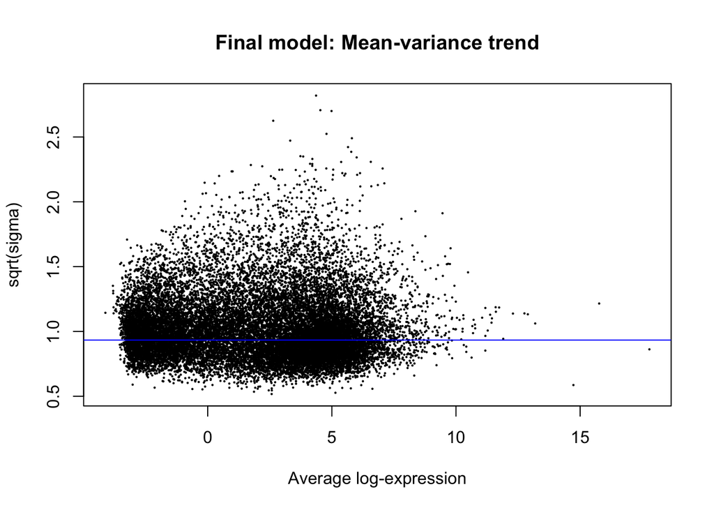

```r
vfit <- lmFit(v, design)
vfit <- contrasts.fit(vfit, contrasts=contr.matrix)
efit <- eBayes(vfit)
plotSA(efit, main="Final model: Mean-variance trend")
```

T-statistics allows for a more stringent definition of significance to be applied to the data. Using the “summary and decide test function”, we are looking at which genes are down-regulated and up-regulated.

```r
summary(decideTests(efit))
```

```
##        BlackVsWhite
## Down              4
## NotSig        20892
## Up                6
```

```r
tfit <- treat(vfit, lfc=0.3)
dt <- decideTests(tfit)
summary(dt)
```

```
##        BlackVsWhite
## Down              3
## NotSig        20895
## Up                4
```

```r
de.common <- which(dt[,1]!=0)
length(de.common)
```

```
## [1] 7
```

```r
head(tfit$genes$SYMBOL[de.common], n=20)
```

```
## [1] NA         NA         NA         NA         "RPS4XP22" "GSTA2"    "POLRMTP1"
```

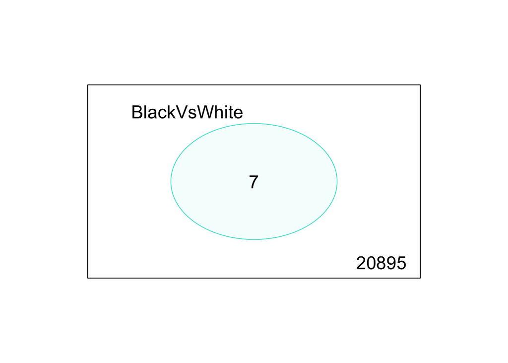

```r
vennDiagram(dt[,1], circle.col=c("turquoise", "salmon"))
```

```r
write.fit(tfit, dt, file="results.txt")
```

I use the “toptreat” function. I list the genes that are most differentially expressed.

```r
Black.vs.White <- topTreat(tfit, coef=1, n=Inf)
head(Black.vs.White)
```

```
##                           ENSEMBL   SYMBOL TXCHROM     logFC    AveExpr
## ENSG00000224237.1 ENSG00000224237     <NA>    <NA>  5.277907 -3.4241652
## ENSG00000226278.1 ENSG00000226278     <NA>    <NA>  6.660566 -0.6268753
## ENSG00000204894.4 ENSG00000204894     <NA>    <NA>  4.480386 -4.1201018
## ENSG00000244067.2 ENSG00000244067    GSTA2    chr6 -4.275477  3.6305746
## ENSG00000239830.1 ENSG00000239830 RPS4XP22    <NA> -2.868156 -2.0649655
## ENSG00000237674.1 ENSG00000237674     <NA>    <NA> -3.565925 -2.8694819
##                           t      P.Value    adj.P.Val
## ENSG00000224237.1  7.846389 3.509852e-09 7.336293e-05
## ENSG00000226278.1  6.985616 4.023201e-08 4.204647e-04
## ENSG00000204894.4  6.586959 1.140285e-07 7.944744e-04
## ENSG00000244067.2 -5.940332 7.280656e-07 3.804507e-03
## ENSG00000239830.1 -5.749682 1.196031e-06 4.999890e-03
## ENSG00000237674.1 -5.448854 2.949800e-06 1.027612e-02
```

I use “plotMD” function to summarize the genes. The log fold change is plot against the log counts per million.

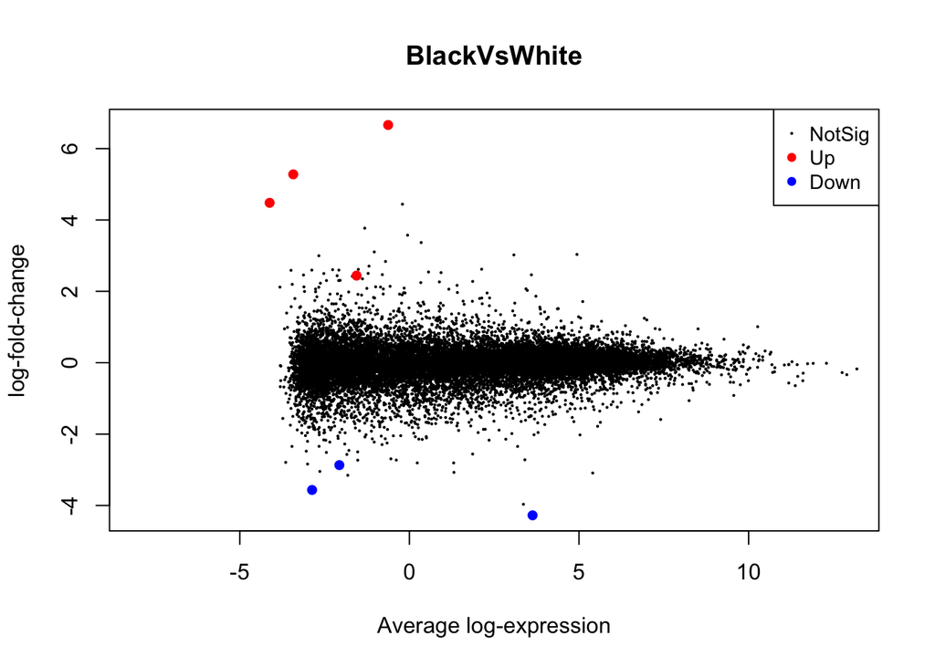

```r
plotMD(tfit, column=1, status=dt[,1], main=colnames(tfit)[1],
       xlim=c(-8,13))
```

The same, we can use glimma to make this interactive.

```r
glMDPlot(tfit, coef=1, status=dt, main=colnames(tfit)[1],
         side.main="ENSEMBL", counts=lcpm, groups=group, launch=TRUE)
```

Finally, I want to plot the differential expression as a heatmap. Heatmap.plus is a library that allows for the creation of heatmaps for larger datasets.

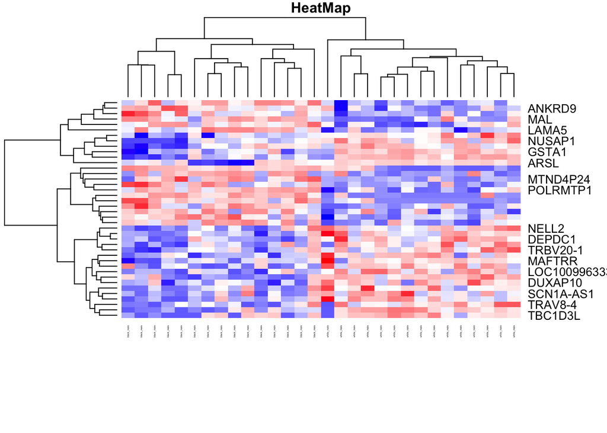

```r
library(gplots)
library(heatmap.plus)
Black.vs.White.topgenes <- Black.vs.White$ENSEMBL[1:40]
i <- which(v$genes$ENSEMBL %in% Black.vs.White.topgenes)
mycol <- colorpanel(1000,"blue","white","red")
par(cex.main=0.8,mar=c(1,1,1,1))
heatmap.plus(lcpm[i,],  scale="row", labRow=v$genes$SYMBOL[i], labCol=group, col=mycol, cexRow=1,cexCol=0.2, margins = c(8,6), main="HeatMap")
```

In this heatmap, red regions are samples with high expression, and blue regions are samples with relatively low expression.

## Gene set testing with camera

I use the camera method to analysize with some gene set testing. The gene set is from the Broad Institute’s Molecular Signatures Database (MSigDB). You can download the Rdata from this link. http://bioinf.wehi.edu.au/software/MSigDB/ After you download, make sure to move it to your working directory.

```r
load("human_c2_v5p2.rdata")
idx <- ids2indices(Hs.c2, rownames(v$genes))
cam.BlackVsWhite <- camera(v,idx,design,contrast=contr.matrix[,1])
head(cam.BlackVsWhite, 7)
```

```
##                                                 NGenes Direction       PValue
## BOWIE_RESPONSE_TO_TAMOXIFEN                         18        Up 0.0002201473
## ISHIKAWA_STING_SIGNALING                             8        Up 0.0014577070
## KERLEY_RESPONSE_TO_CISPLATIN_DN                      3        Up 0.0025414808
## WESTON_VEGFA_TARGETS_12HR                           32        Up 0.0033866837
## OUILLETTE_CLL_13Q14_DELETION_UP                     25      Down 0.0034817457
## KIM_LRRC3B_TARGETS                                  29        Up 0.0041947037
## YAO_TEMPORAL_RESPONSE_TO_PROGESTERONE_CLUSTER_8     37        Up 0.0042757384
##                                                       FDR
## BOWIE_RESPONSE_TO_TAMOXIFEN                     0.9996283
## ISHIKAWA_STING_SIGNALING                        0.9996283
## KERLEY_RESPONSE_TO_CISPLATIN_DN                 0.9996283
## WESTON_VEGFA_TARGETS_12HR                       0.9996283
## OUILLETTE_CLL_13Q14_DELETION_UP                 0.9996283
## KIM_LRRC3B_TARGETS                              0.9996283
## YAO_TEMPORAL_RESPONSE_TO_PROGESTERONE_CLUSTER_8 0.9996283
```

This barcode plot shows the relative enrichment of black male versus white male in clear cell renal cell carcinoma.

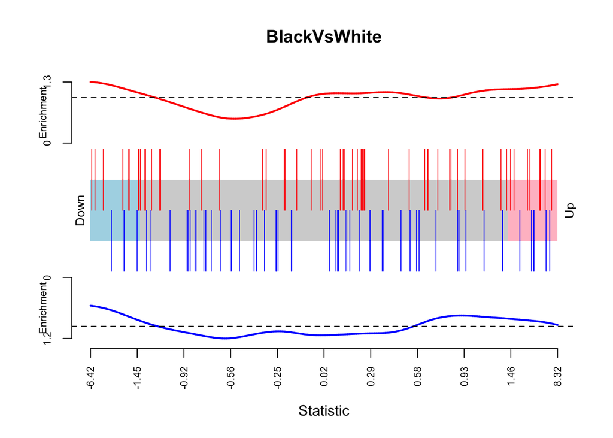

```r
barcodeplot(efit$t[,1], index=idx$LIM_MAMMARY_LUMINAL_MATURE_UP,
            index2=idx$LIM_MAMMARY_LUMINAL_MATURE_DN, main="BlackVsWhite")
```